# Homework3

Buse Yücel - IE582 - Fall 2018 - 2017702153

**1.INTRODUCTION**

In Task 1 there is 3 tasks that needs to be completed.

- In part A, i observed one instance form every classes and all three axes X,Y,Z. In the first gesture , I plotted data for each 3 axes with cumulative sum and without cumulative sum . Moreover, for the other gestures, i observed XYZ plot of data without cumulative sum and cumulative sum data of plot of each 3 axess and total form of xyz axis.
- In Part B, I filtered each test classes’ X,Y and Z axes and after cumulative sum take the last column which is the point that the instance is situated. Afterwards, X,Y and Z axis are combined for each class. Later, i utilized “for loop” in order to combine train and test data for each class’ XYZ axis. Lster, I obtain euclidean and manhattan distances and do .i for each 8 classes. Due to the fact that the only difference is to change class number from 1 to 8, I only added codes for class 1 to the appendix. I filtered each training classes’ X,Y and Z axis and after cumulative sum take the last column which is the point that the instance is situated. Finally, i combined X,Y and Z axis for each class. I performed knn algorithm with 10 fold cross validation to determine the best value of k.
- In Part C, I used rbind function to create the predicted and create a confusion matrix.

In Task 2 there is 4 tasks that needs to be completed.

- In part A, I trained a logistic regression model on the training data by using fused lasso penalties.I used “predict” function to predict the test data and tried to create confusion matrix.
- In part B, I utilized the regression coefficients that i found, I created a plot and tried to interpret it.
- In part C, I took difference between time series by using “diff” function. Later, i repeated the a part.
- In part D , I utilized the regression coefficients that i found in c part. I created a plot and interpretted it.

**2.FIGURES**

**TASK 1**

**Part A**

**For the 1. Class**

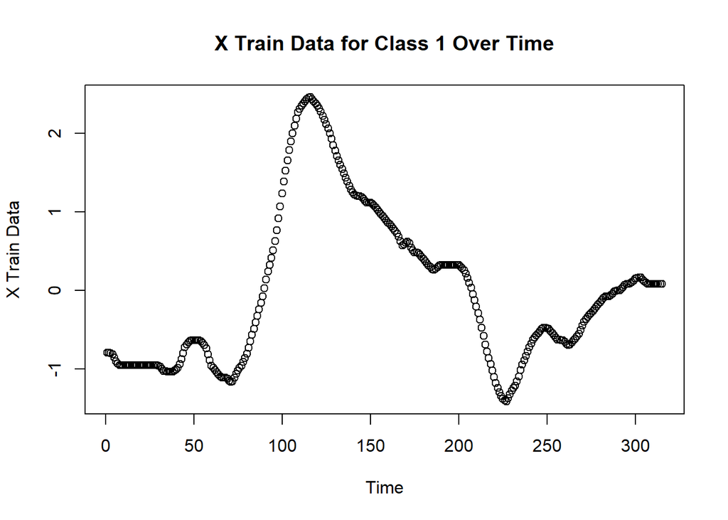

Figure 1: X train data for class 1 over time

x axis of the train data without cumulative sum (For gesture 1)

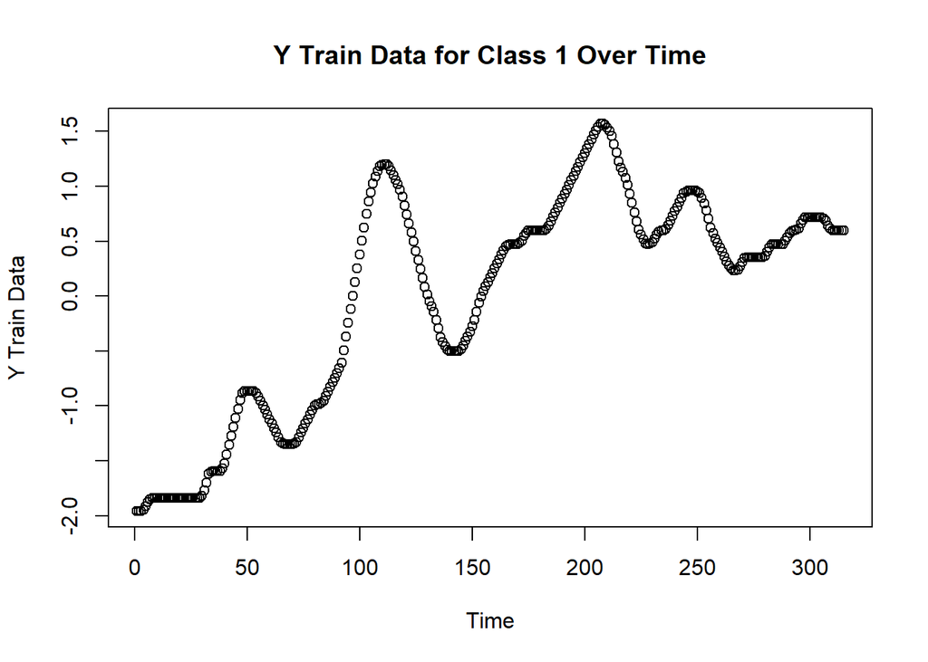

Figure 2: Y train data for class 1 over time

Y axis of the train data without cumulative sum (For gesture 1)

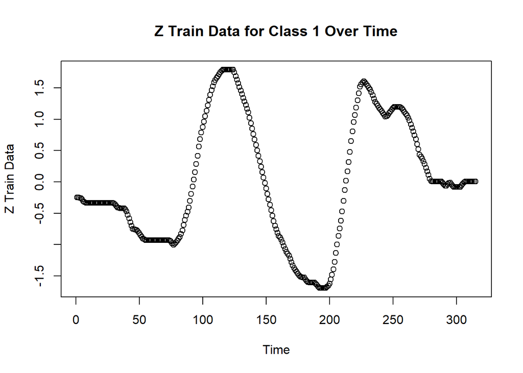

Figure 3: Z train data for class 1 over time

Z axis of the train data without cumulative sum(For gesture 1)

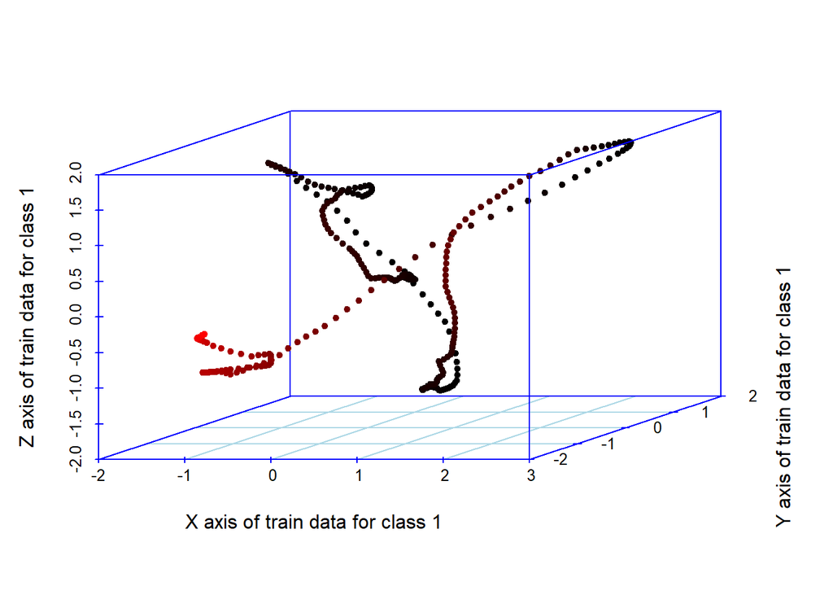

Figure 4: XYZ axis for class 1 without cumulative sum

Vectors are not cumulaive . This plot can be observed to see the combined veriso of axees x,y and z.

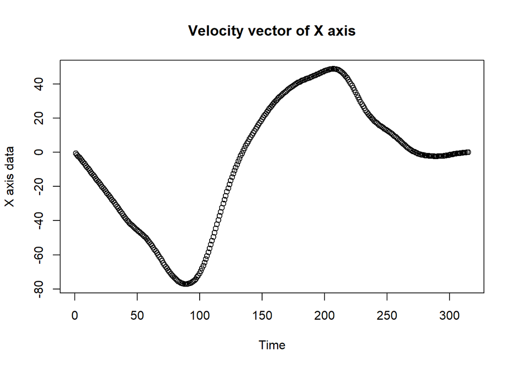

Figure 5: X axis for Class 1 with cumulative sum)

Vectors are cumulative. The plot show the x axis of the training data.

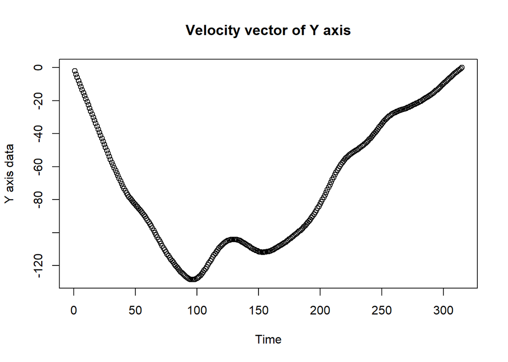

Figure 6: Y axis for Class 1 with cumulative sum

Vectors are cumulative. The plot show the Y axis of the training data.

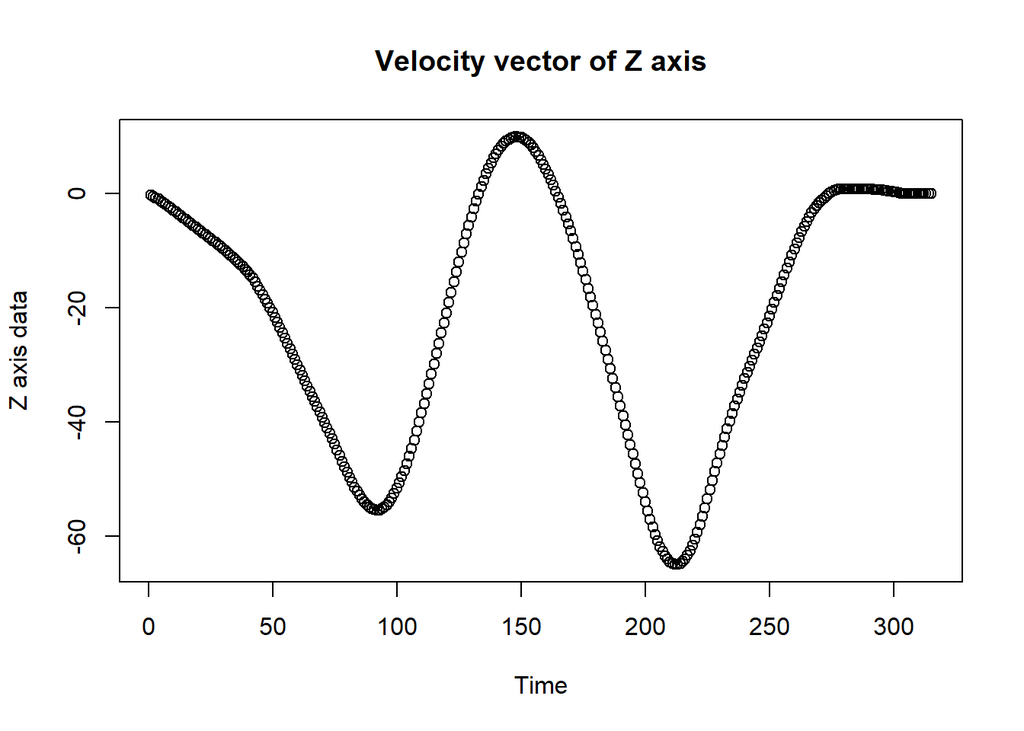

Figure 7: Z axis for Class 1 with cumulative sum

Vectors are cumulative. The plot show the Z axis of the training data.

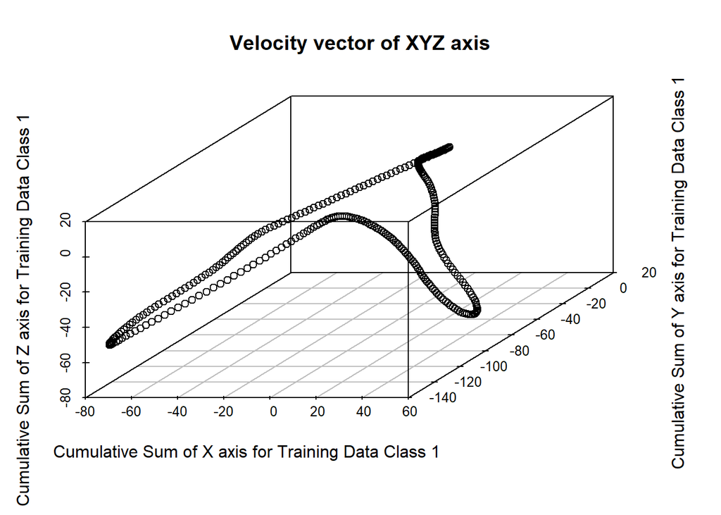

Figure 8: XYZ axis for Class 1 with cumulative sum

This plot shows one instance of Class 1. Vectors are cumulative. The plot show the XYZ axes of the training data.

**For the 2. Class**

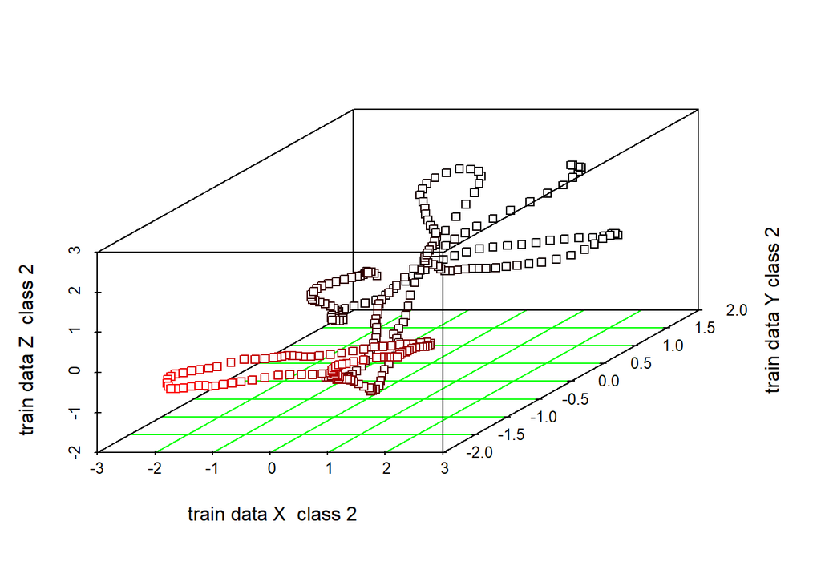

Figure 9: XYZ axis for class 2 without cumulative sum

Vectors are not cumulative. This plot can be utilized to observe the combined version of x,y and z axes.

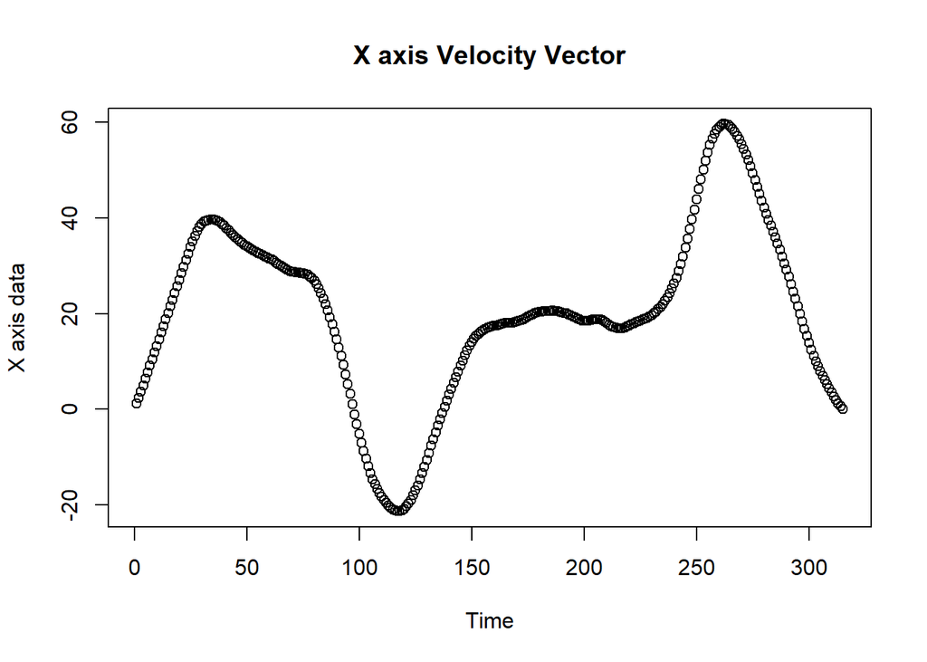

Figure 10: X axis for Class 2 with cumulative sum(Velocity vector of X axis)

Cumulative sum is taken in to account.X axis of the training data can be seen from this plot.

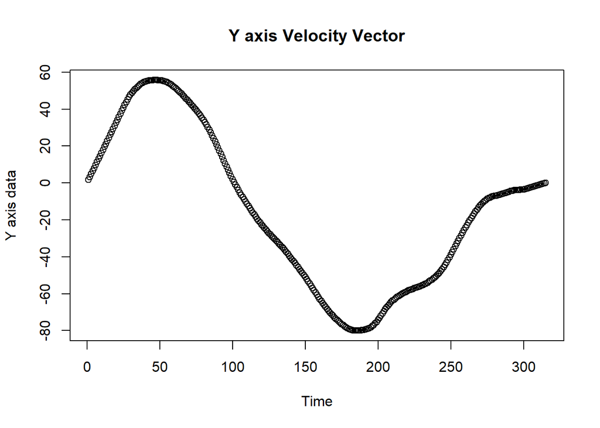

Figure 11: Y axis for Class 2 with cumulative sum(Velocity vector of Y axis)

Cumulative sum is taken in to account.Y axis of the training data can be seen from this plot.

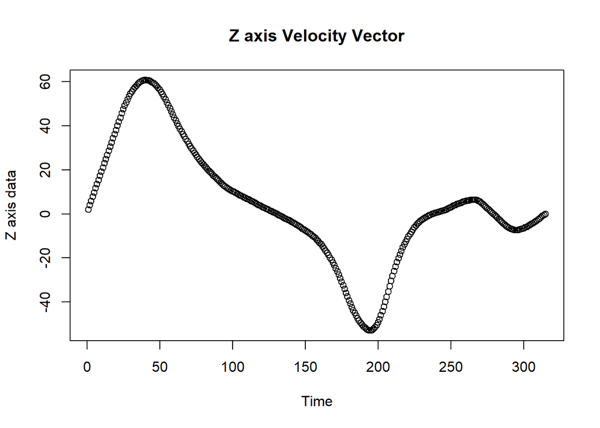

Figure 12: Z axis for Class 2 with cumulative sum(Velocity vector of Z axis)

Cumulative sum is taken in to account.Z axis of the training data can be seen from this plot.

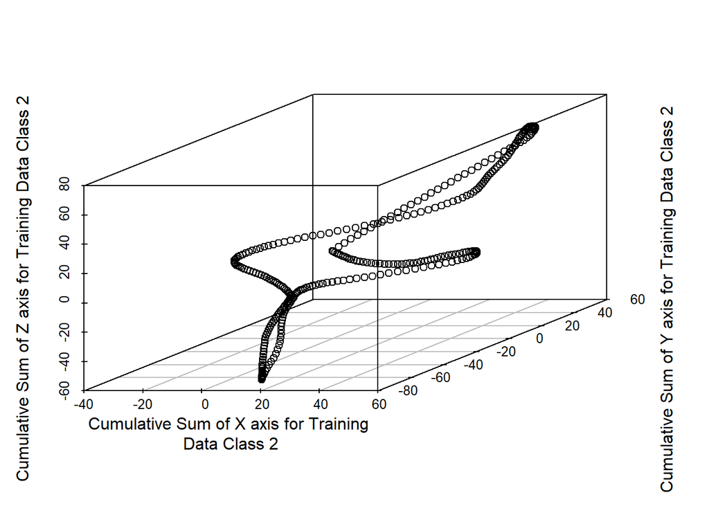

Figure 13: XYZ axis for Class 2 with cumulative sum(Velocity vector of XYZ axis)

Cumulative sum is taken in to account. XYZ axis of the training data can be seen from this plot. The plot visualizes one instance of Class 2.

**For the 3. Class**

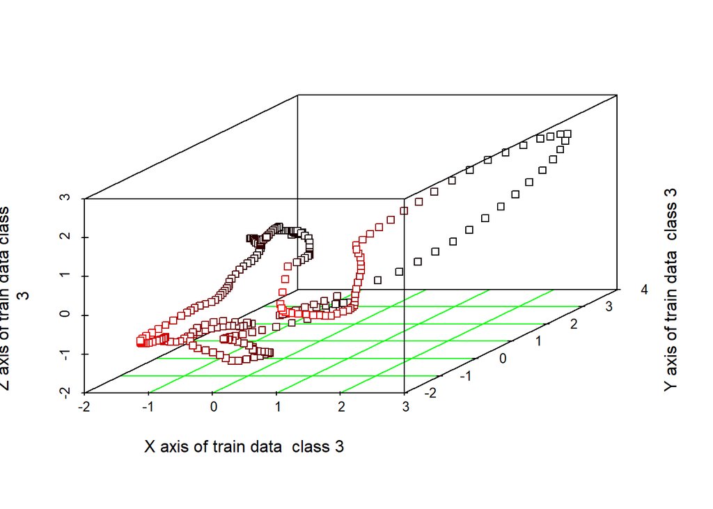

Figure 14: XYZ axis for class 3 without cumulative sum

Vectors are not cumulative.This plot can be utilized to see the combined version of x,y and z axis.

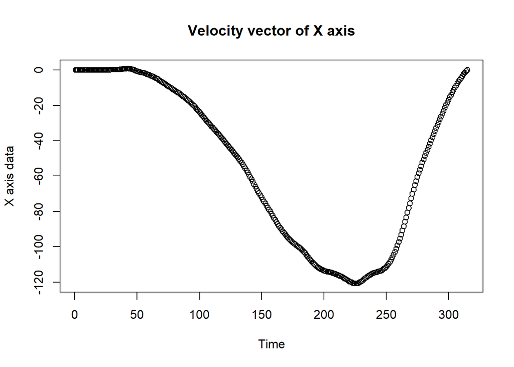

Figure 15: X axis for Class 3 with cumulative sum(Velocity vector of X axis)

Cumulative sum is taken in to account.X axis of the training data can be seen from this plot.

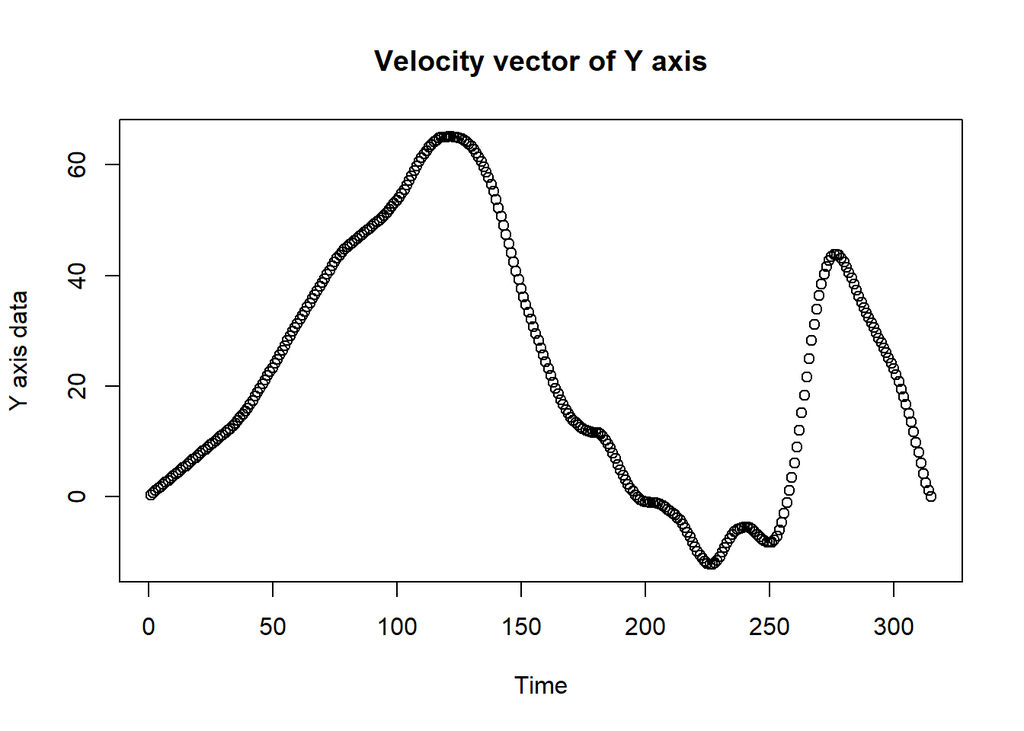

Figure 16: Y axis for Class 3 with cumulative sum(Velocity vector of Y axis)

Cumulative sum is taken in to account.Y axis of the training data can be seen from this plot.

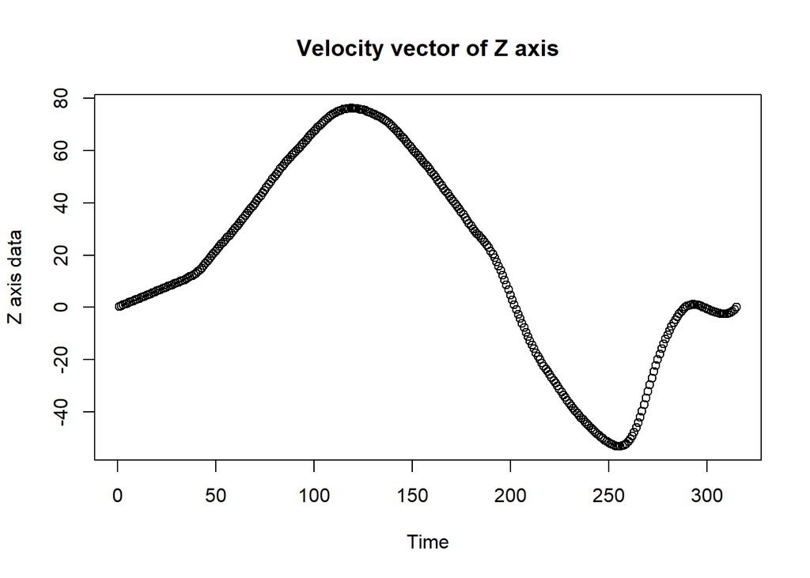

Figure 17: Z axis for Class 3 with cumulative sum(Velocity vector of Z axis)

Cumulative sum is taken in to account.Z axis of the training data can be seen from this plot.

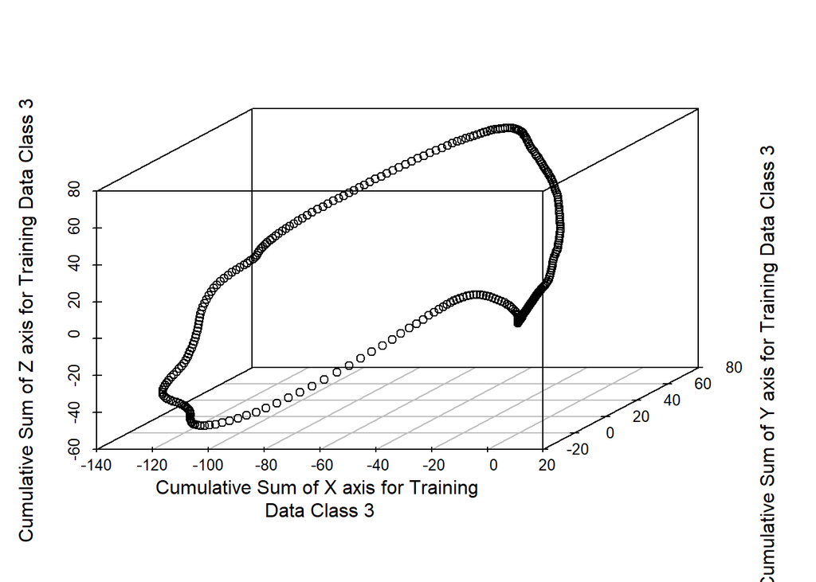

Figure 18: XYZ axis for Class 3 with cumulative sum(Velocity vector of XYZ axis)

Cumulative sum is taken in to account. XYZ axis of the training data can be seen from this plot. The plot visualizes one instance of Class 3.

**For the 4. Class**

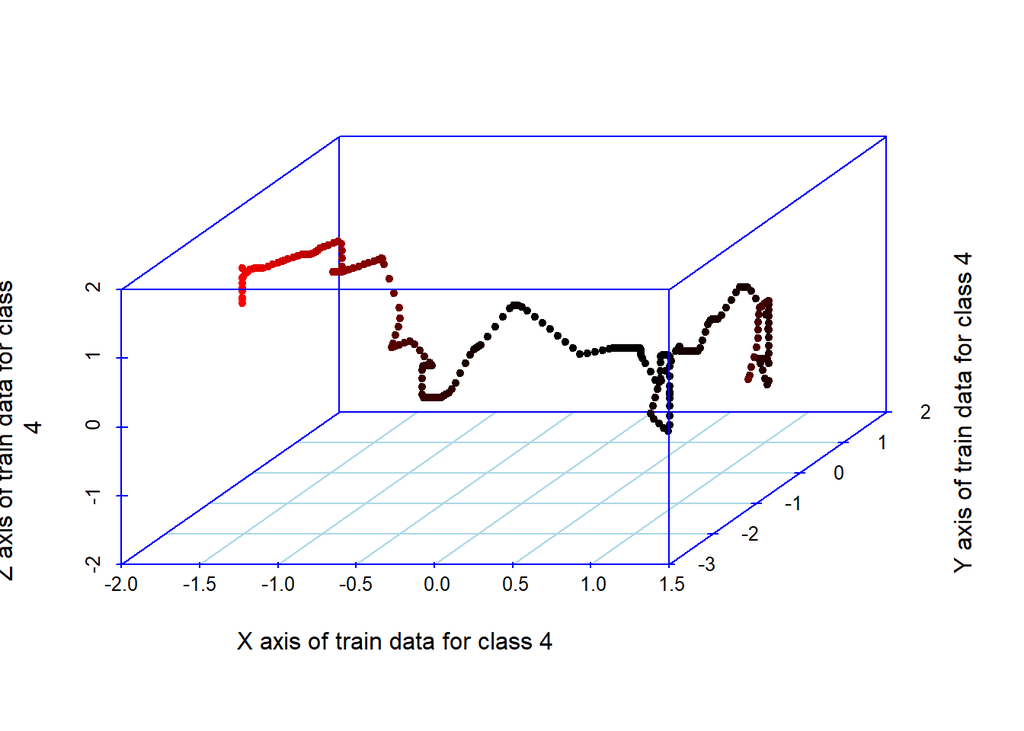

Figure 19: XYZ axis for class 4 without cumulative sum

If I want to see the combined version of x,y and z axis, this kind of plot can be observed.In this case, vectors are not cumulative.

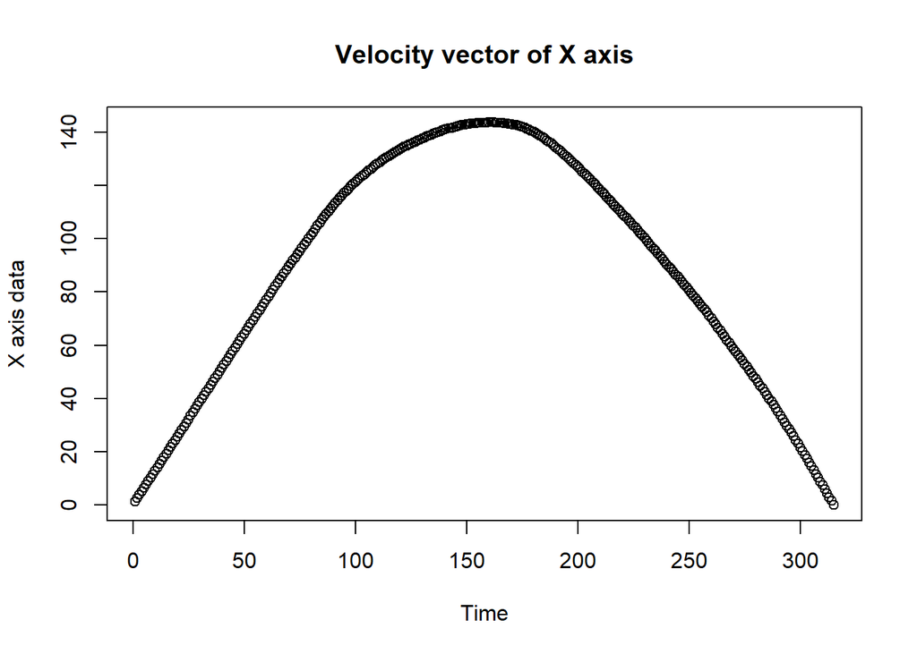

Figure 20: X axis for Class 4 with cumulative sum(Velocity vector of X axis)

This shows the graph of x axis belonging training data. In this case, cumulative sum is considered.

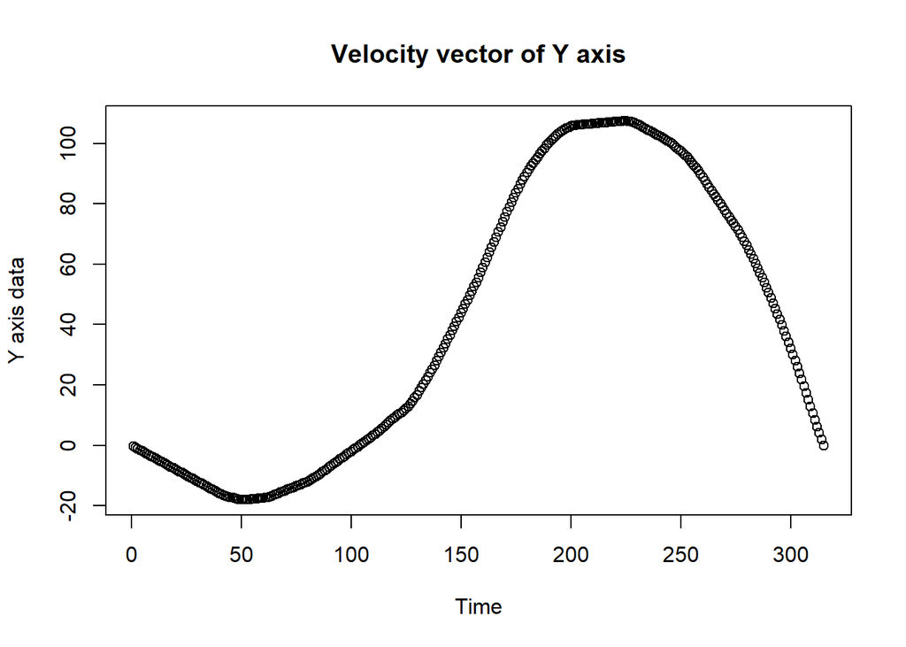

Figure 21: Y axis for Class 4 with cumulative sum(Velocity vector of Y axis)

This shows the graph of y axis belonging training data. In this case, cumulative sum is considered.

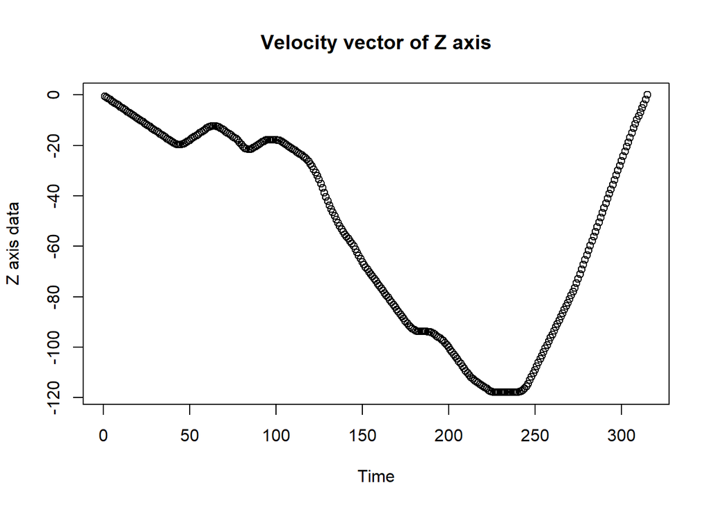

Figure 22: Z axis for Class 4 with cumulative sum(Velocity vector of Z axis)

This shows the graph of z axis belonging training data. In this case, cumulative sum is considered.

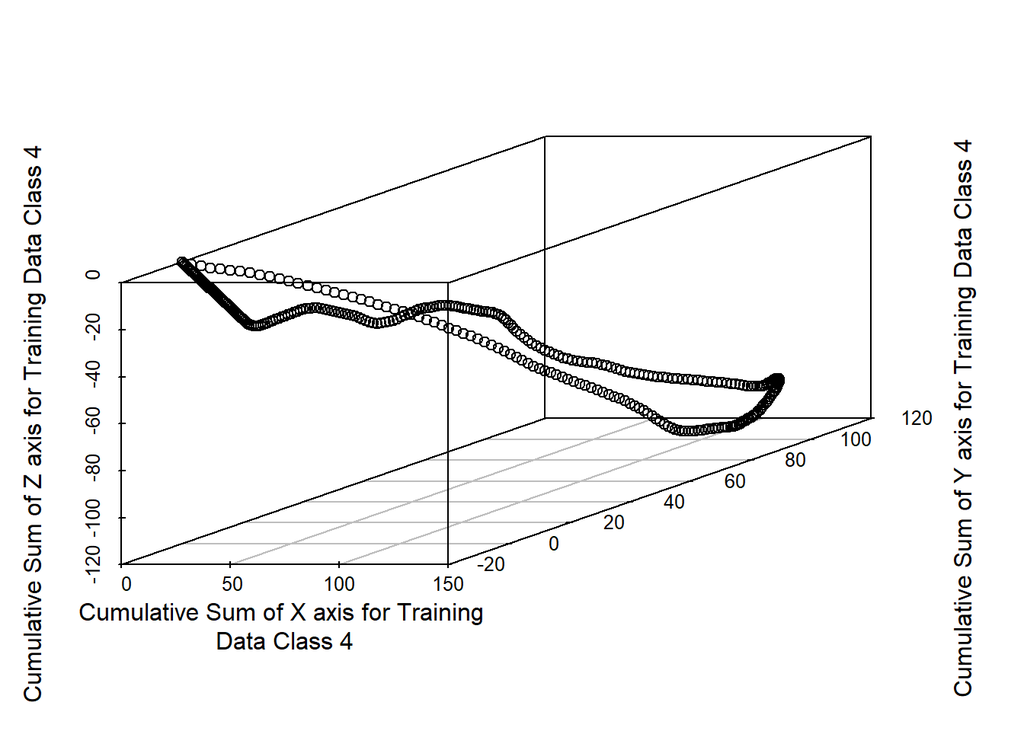

Figure 23: XYZ axis for Class 4 with cumulative sum(Velocity vector of XYZ axis)

This shows the graph of xyz axis belonging training data. In this case, cumulative sum is considered. This is the visualization of one instance of Class 4.

**For the 5. Class**

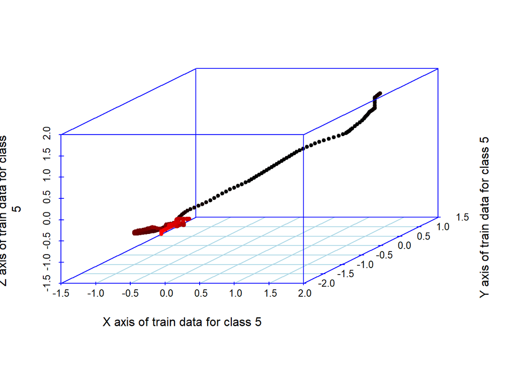

Figure 24: XYZ axis for class 5 without cumulative sum

If I want to see the combined version of x,y and z axis, this kind of plot can be observed.In this case, vectors are not cumulative.

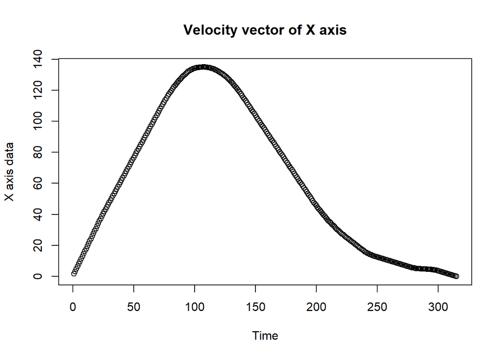

Figure 25: X axis for Class 5 with cumulative sum(Velocity vector of X axis)

This shows the graph of x axis belonging training data. In this case, cumulative sum is considered.

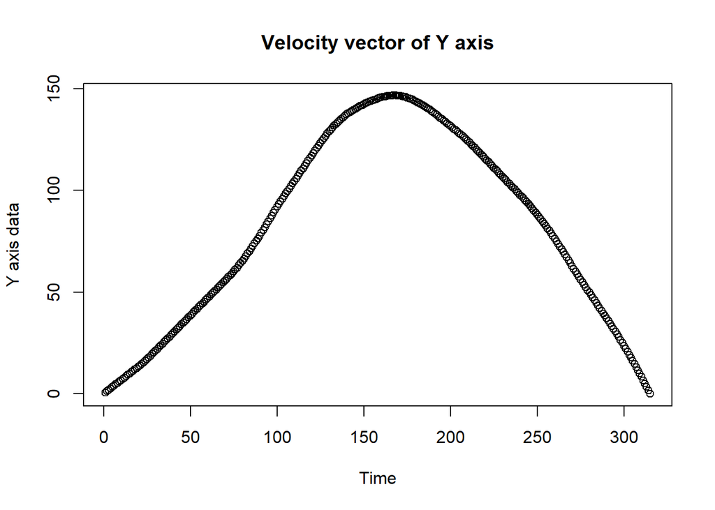

Figure 26: Y axis for Class 5 with cumulative sum(Velocity vector of Y axis)

This shows the graph of y axis belonging training data. In this case, cumulative sum is considered.

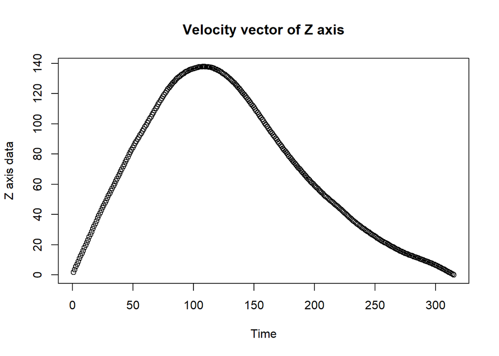

Figure 27: Z axis for Class 5 with cumulative sum(Velocity vector of Z axis)

This shows the graph of z axis belonging training data. In this case, cumulative sum is considered.

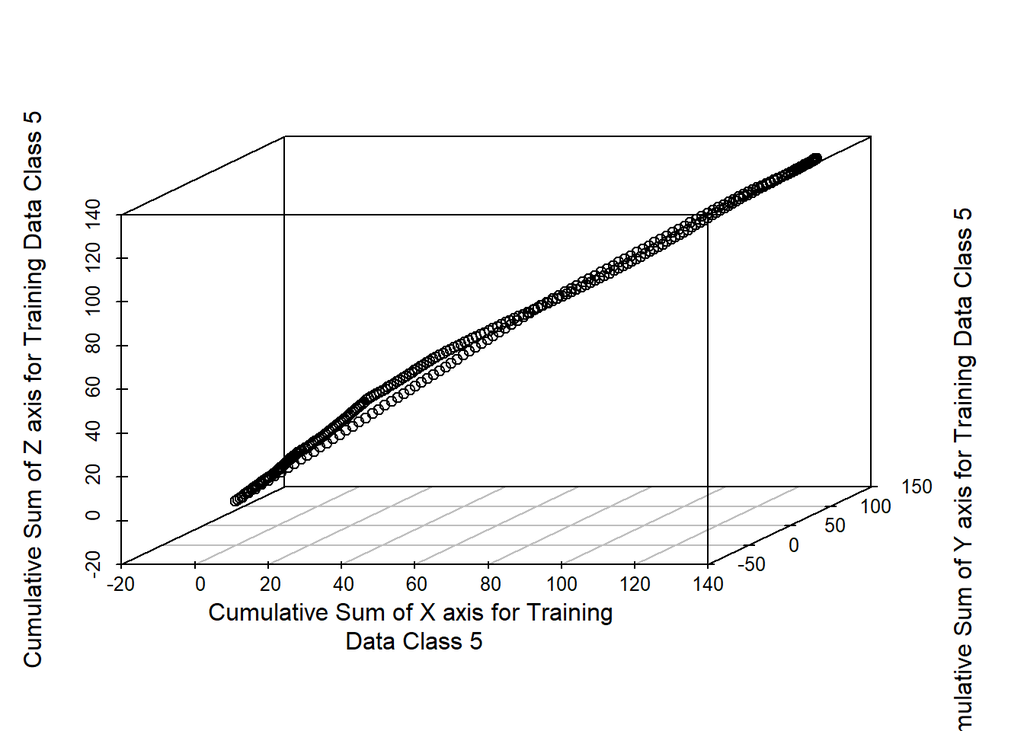

Figure 28: XYZ axis for Class 5 with cumulative sum(Velocity vector of XYZ axis)

This shows the graph of xyz axis belonging training data. In this case, cumulative sum is considered. This is the visualization of one instance of Class 5.

**For the 6. Class**

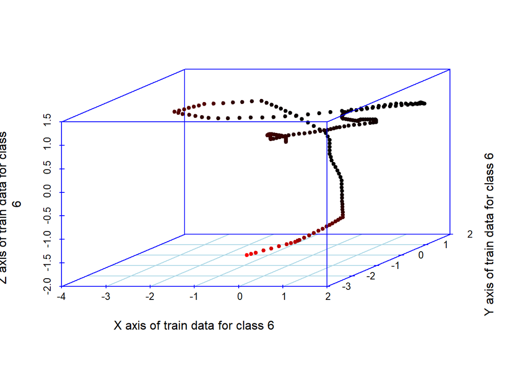

Figure 29: XYZ axis for class 6 without cumulative sum

If I want to see the combined version of x,y and z axis, this kind of plot can be observed.In this case, vectors are not cumulative.

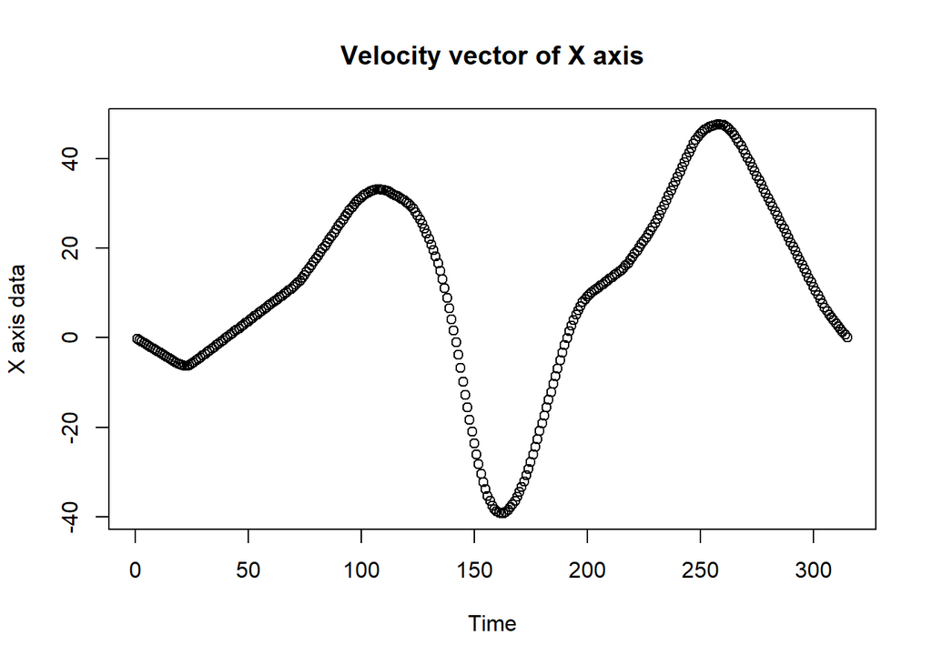

Figure 30: X axis for Class 6 with cumulative sum(Velocity vector of X axis)

This shows the graph of x axis belonging training data. In this case, cumulative sum is considered.

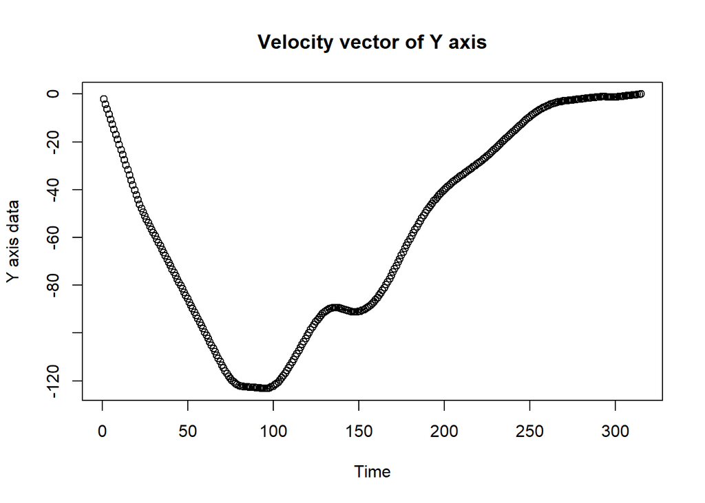

Figure 31: Y axis for Class 6 with cumulative sum(Velocity vector of Y axis)